# iLykei Lecture Series Machine Learning Support Vector Machines Workshop 1

Y.Balasanov, L.Nazarov, © iLykei 2016-2022

# 1 Introduction

Support Vector learning is based on simple, but deep ideas which originated in statistical learning theory. The simplicity comes from the fact that Support Vector Machines (SVMs) apply a simple linear method to the data but in a high-dimensional feature space which is non-linearly related to the input space.  
Even though we can think of SVMs as a linear algorithm in a high-dimensional space, in practice, it does not involve any computations in that high dimensional space. The only necessary operation is dot product.  
This simplicity combined with outstanding performance on many learning problems (classification, regression, and pattern recognition) has contributed to the popularity of the SVM.  
Currently four R packages contain SVM related software. The review and comparison of these implementations can be found in A. Karatzoglou, D. Meyer, K. Hornik. [Support Vector Machines in R](https://www.jstatsoft.org/article/view/v015i09/v15i09.pdf).

# 2 Maximal Margin Classifier

The idea underlying Maximal margin classifier is easy and intuitive. It was suggested by Vladimir N. Vapnik and Alexey Ya. Chervonenkis in 1963. Their approach to solving binary classification problem may be roughly sketched as follows.  
We are looking for two parallel hyperplanes $H_1$, $H_2$, separating two classes with maximal distance between $H_1$ and $H_2$.  
The set of points equidistant from $H_1$ and $H_2$ is called maximal margin classifier or optimal separating hyperplane. Margin here is the distance between $H_1$ and $H_2$.  
Draw two-dimensional picture illustrating these concepts. Suppose elements of the classes have two numerical features. So we can treat them as points on the plane. Elements of the first class are red.

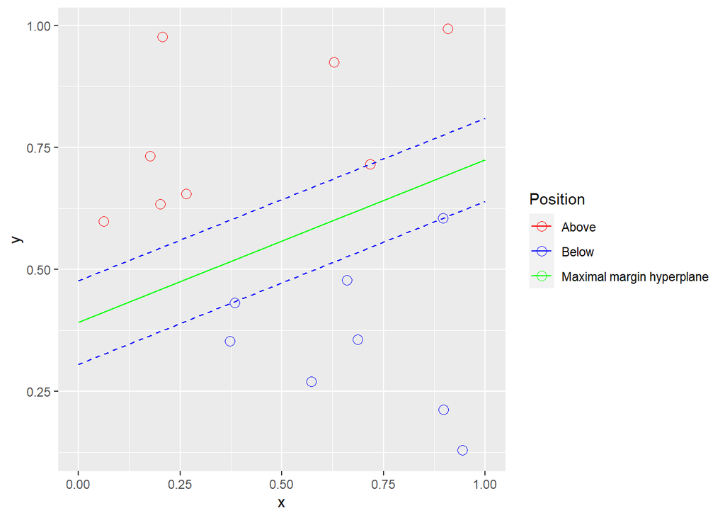

Blue dashed lines are hyperplanes $H_1$ and $H_2$. Green solid line is optimal separating hyperplane. The observation points on $H_1$ or $H_2$ are called support vectors.

# 3 Linear SVM

Consider binary classification problem with class labels $Y = \{ -1,1 \}$ and a learning sample $L^n = {(x_1,y_1),..,(x_n,y_n)}$.
The goal is finding the maximum-margin hyperplane that divides the classes so that the distance between the hyperplane and the nearest point from either class is maximized.
A hyperplane equation is
$$w \cdot x-b=0,$$
where $w \cdot x$ is dot product and $w$ is orthogonal vector to hyperplane.
If the learning sample is linearly separable, we can select two parallel hyperplanes with the equations
$$w \cdot x-b=1,\; w \cdot x-b=-1$$
that separate the data into two classes, so that the distance between them is as large as possible. Geometrically, the distance between these two hyperplanes is $\frac{2}{\left\Vert w\right\Vert }$, so the goal is to minimize $\left\Vert w\right\Vert$ with the constraints
$$y_i\left( w \cdot x_i-b\right) \geqslant 1, \; i=1,...,n$$
Maximum-margin hyperplane is completely determined by the points from both classes with nearest location to it. These points are called support vectors.

Unfortunately often the data are not linearly separable. In order to extend the method to such cases the hinge loss function was introduced
$$h_i(w)=\max_{1\leqslant i\leqslant n} (0,1-y_i\left( w \cdot x_i-b\right)).$$
It imposes penalty proportional to the distance from the margin on misclassified points.

Minimization of loss function
$$L(w) = \sum_{i=1}^{n}h_{i}(w)+\lambda \left\Vert w\right\Vert ^{2}$$
gives solution $w^*(\lambda )$, dependent on $\lambda$. Larger $\lambda$ increases margin but may reduce the number of points on the correct side of it.

# 4 Support Vector Machines

B. Boser, I. Guyon, and V. Vapnik (1992) suggested a way of creating nonlinear classifiers by applying the kernel trick based on transformation of input space $\phi$ and the kernel $K$. They are related as
$$K(x_1,x_2)=(\phi (x_1) \cdot \phi (x_2)).$$
The resulting algorithm is formally similar, except that every dot product is replaced by a non-linear kernel function.
Some common kernels include:
* Polynomial (homogeneous): $K(x_i,x_j)=(x_i \cdot x_j)^d$
* Polynomial (inhomogeneous): $K(x_i,x_j)=(x_i \cdot x_j + 1)^d$
* Gaussian radial basis function: $K(x_i,x_j)=\exp(-\gamma \|x_i - x_j\|^2),$ for $\gamma > 0$. Sometimes parameterized using $\gamma=\frac{1}{2 \sigma^2}$
* Hyperbolic tangent: $K(x_i,x_j)=\tanh(\kappa x_i \cdot x_j+c),$ for some (not every) $\kappa > 0$ and $c < 0$

Watch [visualisation of kernel trick](https://www.youtube.com/watch?v=3liCbRZPrZA)

To learn more about SVM watch an excellent lecture by [Patrick Henri Winston at MIT OpenCourseWare](https://ocw.mit.edu/courses/electrical-engineering-and-computer-science/6-034-artificial-intelligence-fall-2010/lecture-videos/lecture-16-learning-support-vector-machines/).

# 5 Package e1071

This is the first implementation of SVM in R (R Development Core Team, 2005).  
Description: Functions for latent class analysis, fast Fourier transform, fuzzy clustering, support vector machines, shortest path computation, bagged clustering, naive Bayes classifier, …  
Reference manual: e1071.pdf

# 6 Regression

```r
library(e1071)
```

## 6.1 Example. Predicting Baseball Players’ Salaries

Use the Hitters data from the ISLR library for a simple example

```r
library(ISLR)
library(knitr)
# Remove incomplete cases
Hitters <- na.omit(Hitters)
```

```r
# log transform Salary to make it more normally distributed
Hitters$Salary <- log(Hitters$Salary)
kable(head(Hitters,3))
```

|  | AtBat | Hits | HmRun | Runs | RBI | Walks | Years | CAtBat | CHits | CHmRun | CRuns | CRBI | CWalks | League | Division | PutOuts | Assists | Errors | Salary | NewLeague |
| --- | --- | --- | --- | --- | --- | --- | --- | --- | --- | --- | --- | --- | --- | --- | --- | --- | --- | --- | --- | --- |
| -Alan Ashby | 315 | 81 | 7 | 24 | 38 | 39 | 14 | 3449 | 835 | 69 | 321 | 414 | 375 | N | W | 632 | 43 | 10 | 6.163315 | N |
| -Alvin Davis | 479 | 130 | 18 | 66 | 72 | 76 | 3 | 1624 | 457 | 63 | 224 | 266 | 263 | A | W | 880 | 82 | 14 | 6.173786 | A |
| -Andre Dawson | 496 | 141 | 20 | 65 | 78 | 37 | 11 | 5628 | 1575 | 225 | 828 | 838 | 354 | N | E | 200 | 11 | 3 | 6.214608 | N |

Fit the model by calling `svm()` function. The function runs support vector regression, but it will automatically choose SVM if it detects that the data are categorical (if the variable is a factor in R).

```r
svmHitters <- svm(Salary~.  , Hitters)
cat("MSE = ",sum(svmHitters$residuals^2)/nrow(Hitters))
```

```
## MSE =  0.1345768
```

```r
summary(svmHitters)
```

```
##
## Call:
## svm(formula = Salary ~ ., data = Hitters)
##
##
## Parameters:
##    SVM-Type:  eps-regression
##  SVM-Kernel:  radial
##        cost:  1
##       gamma:  0.05
##     epsilon:  0.1
##
##
## Number of Support Vectors:  213
```

```r
names(svmHitters)
```

```
##  [1] "call"            "type"            "kernel"          "cost"
##  [5] "degree"          "gamma"           "coef0"           "nu"
##  [9] "epsilon"         "sparse"          "scaled"          "x.scale"
## [13] "y.scale"         "nclasses"        "levels"          "tot.nSV"
## [17] "nSV"             "labels"          "SV"              "index"
## [21] "rho"             "compprob"        "probA"           "probB"
## [25] "sigma"           "coefs"           "na.action"       "fitted"
## [29] "decision.values" "residuals"       "terms"
```

With even default parameters we got better result than random forest (see previous lecture).

Plot

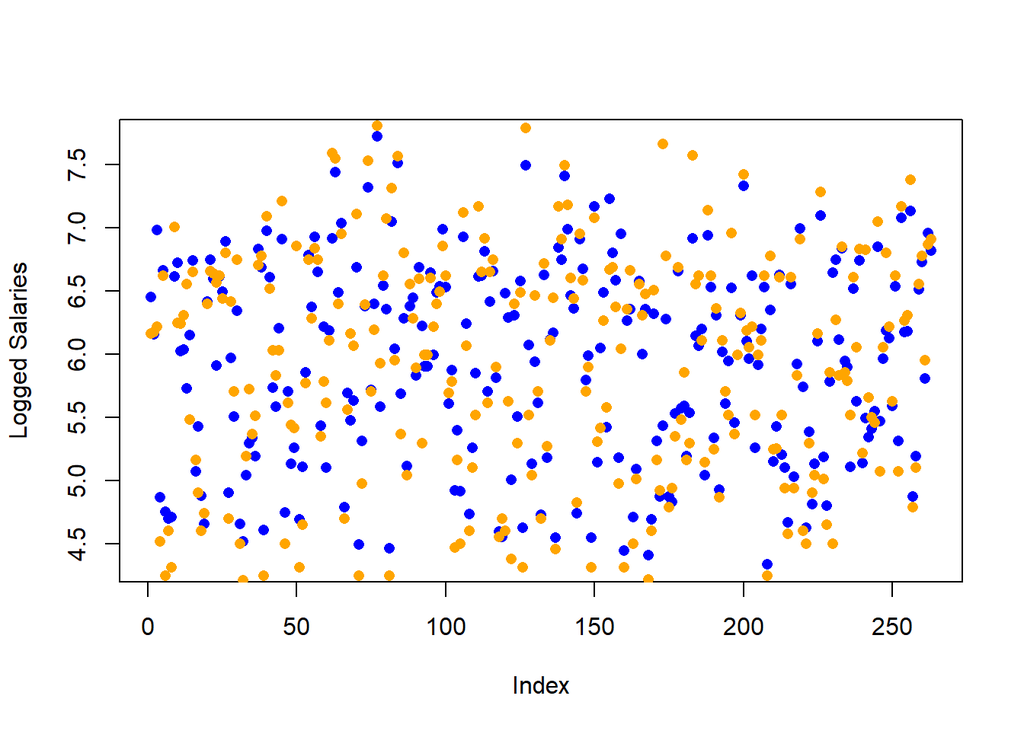

```r
plot(1:dim(Hitters)[1],svmHitters$fitted,type="p",pch=16,col="blue",
     ylab="Logged Salaries",xlab="Index")
points(1:dim(Hitters)[1],Hitters$Salary,type="p",col="orange",pch=16)
```

## 6.2 Example. Large Number of Predictors

Consider the example analysed in the workshop Linear Regression with Large Number of Predictors. Simulate data

```r
N = 500
set.seed(0)
Epsilon<-rnorm(N,0,1)
X<-rnorm(N*N,0,2)
dim(X)<-c(N,N)
colnames(X)<-paste0("X",1:N)
slopesSet<-runif(N,1,3)
Y<-sapply(2:N,function(z) 1+X[,1:z]%*%slopesSet[1:z]+Epsilon)
head(X[,1:5])
```

```
##              X1         X2         X3          X4         X5
## [1,] -1.2527365 -0.5737031  0.1575234  0.88869164 -1.0643804
## [2,]  0.9626707  3.6822138 -0.1028412  0.02385876 -0.7399334
## [3,]  3.3905422 -0.3135286 -0.5215483 -0.01856009  2.3417986
## [4,] -3.5224526 -2.7796053  3.1325364 -0.60475511 -0.9291356
## [5,]  0.3960260 -2.9462080 -0.7440302  0.98471004 -0.6042920
## [6,]  0.7946982 -0.1390379  3.4838889 -1.20543924  2.7827418
```

```r
m = 440
completeModelDataFrame <- data.frame(Y=Y[,m-1],X[,1:m])
```

Fit the model.

```r
svmManyRegressors <- svm(Y~.  , completeModelDataFrame)
cat("MSE = ",sum(svmManyRegressors$residuals^2)/nrow(completeModelDataFrame))
```

```
## MSE =  819.5547
```

Far from linear regression but much better than any of the tree methods.

# 7 Classification

## 7.1 Simple example

Create a classification example with 4 points and 2 classes.

```r
dat<-rbind(c(1,1,1),
           c(2,1,0),
           c(2,2,1),
           c(1,2,0))
colnames(dat)<-c("X1","X2","Class")
dat<-as.data.frame(dat)
dat$Class<-as.factor(dat$Class)
dat
```

```
##   X1 X2 Class
## 1  1  1     1
## 2  2  1     0
## 3  2  2     1
## 4  1  2     0
```

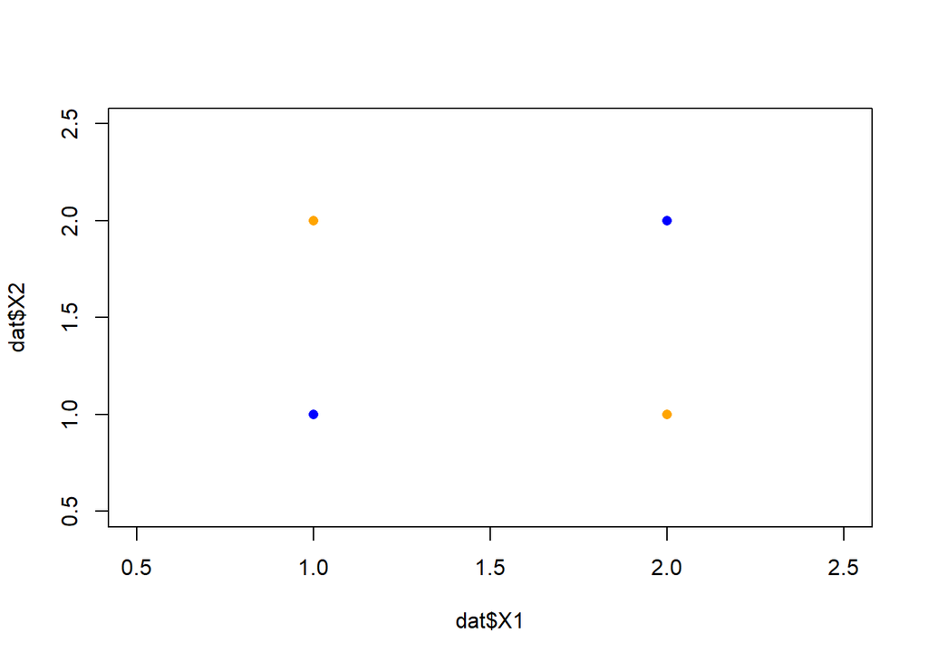

```r
plot(dat$X1,dat$X2,col="orange",pch=16,ylim=c(0.5,2.5),xlim=c(0.5,2.5))
points(dat$X1[dat$Class==1],dat$X2[dat$Class==1],col="blue",pch=16)
```

1. Fit SVM classifier with linear kernel.

```r
m1<-svm(Class~.  , data=dat,kernel="linear")
(m1.pred<-predict(m1))
```

```
## 1 2 3 4
## 0 0 0 0
## Levels: 0 1
```

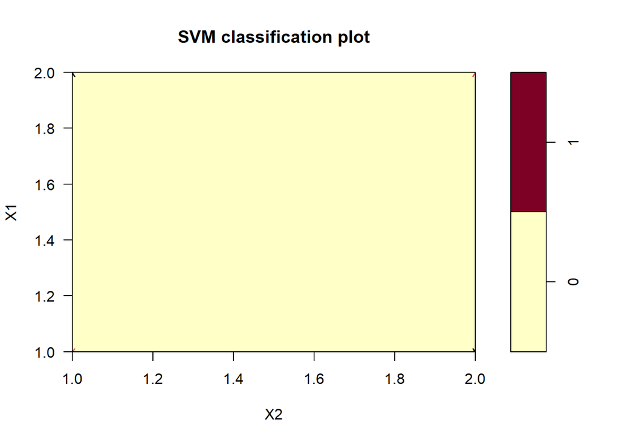

```r
plot(m1,dat)
```

Linear kernel did not work because points are not linearly separable.

2. Use polynomial kernel of degree 2.

```r
m1<-svm(Class~.  , data=dat,kernel="polynomial",degree=2)
(m1.pred<-predict(m1))
```

```
## 1 2 3 4
## 1 0 1 0
## Levels: 0 1
```

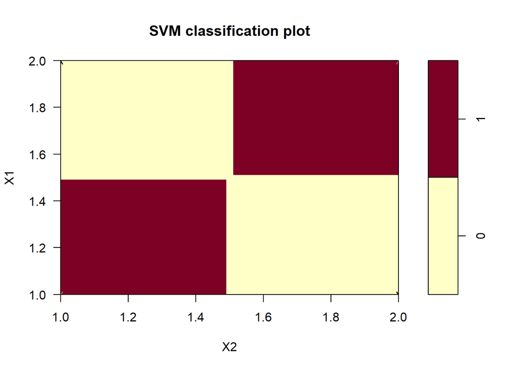

```r
plot(m1,dat)
```

Second degree polynomial gives correct solution.

3. Use polynomial kernel with degree 3.

```r
m1<-svm(Class~.  , data=dat,kernel="polynomial",degree=3)
(m1.pred<-predict(m1))
```

```
## 1 2 3 4
## 0 0 0 0
## Levels: 0 1
```

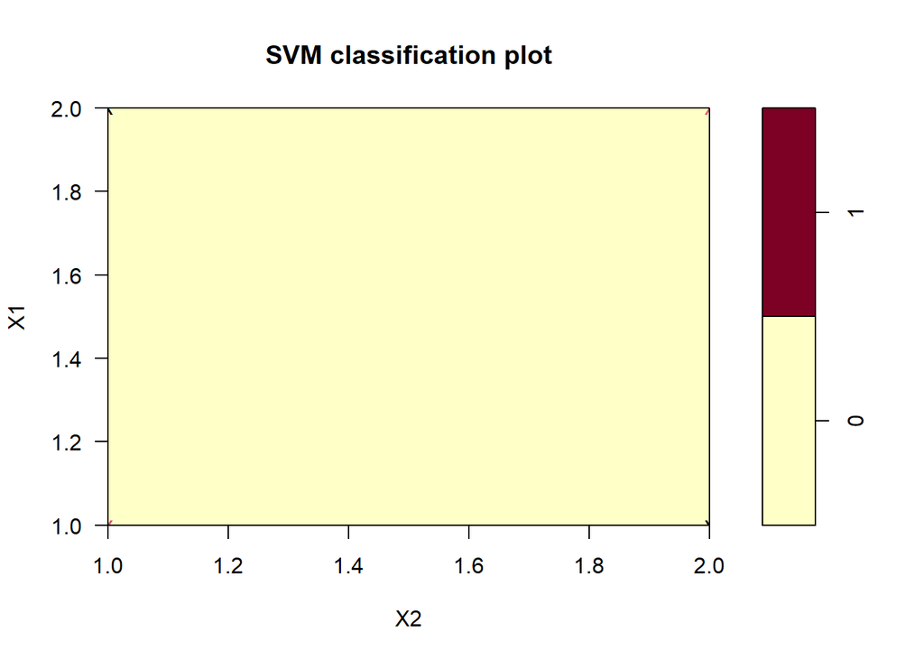

```r
plot(m1,dat)
```

Obviously, the higher polynomial degree is not the better.

4. Use radial or Gaussian kernel.

```r
m1<-svm(Class~.  , data=dat,kernel="radial")
(m1.pred<-predict(m1))
```

```
## 1 2 3 4
## 1 0 1 0
## Levels: 0 1
```

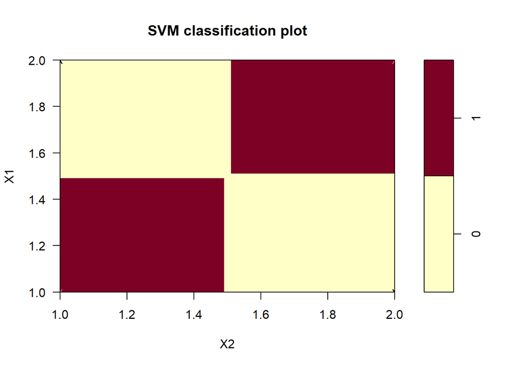

```r
plot(m1,dat)
```

This kernel is the most universal.

## 7.2 Sine wave example

Use simple example from lecture 7 with a trigonometric signal, plus noise.  
Make one class a sine wave and another - a cosine wave.

```r
set.seed(1180)
x<-seq(0,2*pi,by=.01)
sigmaEps<-.5
eps<-rnorm(length(x),0,sigmaEps)
signal<-sin(x)+eps
data1<-data.frame(x=x,signal=signal)
head(data1)
```

```
##      x     signal
## 1 0.00  0.7868680
## 2 0.01 -0.8655367
## 3 0.02 -0.3215762
## 4 0.03  0.2279028
## 5 0.04 -0.2668126
## 6 0.05  0.3780676
```

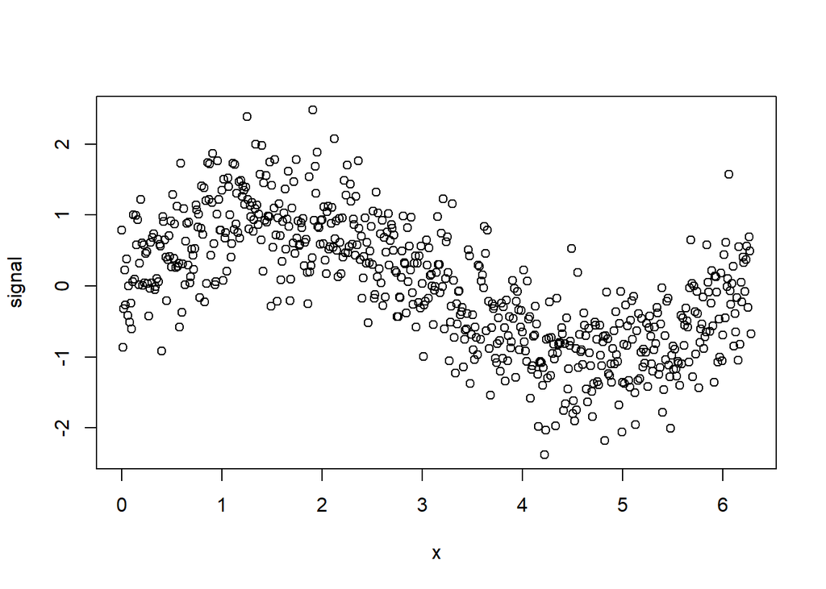

```r
plot(data1)
```

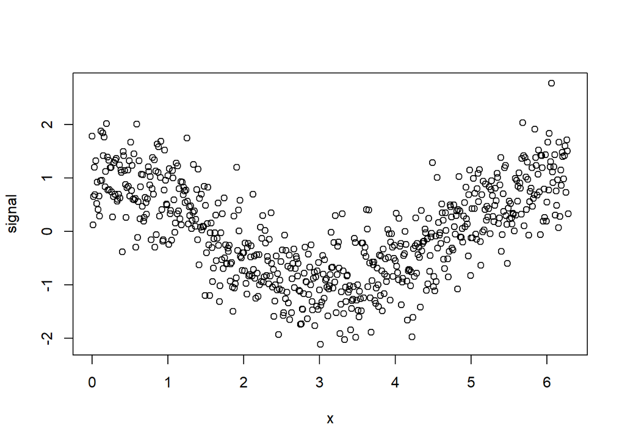

```r
data2<-data.frame(x=x,signal=cos(x)+eps)
plot(data2)
```

Plot the data together.

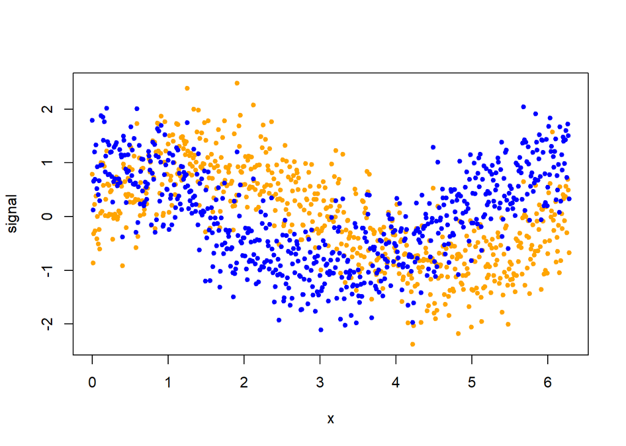

```r
plot(data1,pch=20,col="orange")
points(data2,pch=20,col="blue")
```

Combine the data in one data frame

```r
data1$class<-1
data2$class<-2
dataClasses<-rbind(data1,data2)
head(dataClasses)
```

```
##      x     signal class
## 1 0.00  0.7868680     1
## 2 0.01 -0.8655367     1
## 3 0.02 -0.3215762     1
## 4 0.03  0.2279028     1
## 5 0.04 -0.2668126     1
## 6 0.05  0.3780676     1
```

### 7.2.1 SVM with radial kernel

Radial kernel is the default:
$$K(u,v)=e^{-\gamma |u-v|^2}.$$

```r
svmFit.radial <- svm(class~., data = dataClasses)
summary(svmFit.radial)
```

```
##
## Call:
## svm(formula = class ~ ., data = dataClasses)
##
##
## Parameters:
##    SVM-Type:  eps-regression
##  SVM-Kernel:  radial
##        cost:  1
##       gamma:  0.5
##     epsilon:  0.1
##
##
## Number of Support Vectors:  1025
```

```r
names(svmFit.radial)
```

```
##  [1] "call"            "type"            "kernel"          "cost"
##  [5] "degree"          "gamma"           "coef0"           "nu"
##  [9] "epsilon"         "sparse"          "scaled"          "x.scale"
## [13] "y.scale"         "nclasses"        "levels"          "tot.nSV"
## [17] "nSV"             "labels"          "SV"              "index"
## [21] "rho"             "compprob"        "probA"           "probB"
## [25] "sigma"           "coefs"           "na.action"       "fitted"
## [29] "decision.values" "residuals"       "terms"
```

```r
head(svmFit.radial$decision.values)
```

```
##            /
## 1  0.4393962
## 2 -1.1136125
## 3 -1.0991467
## 4 -0.6586668
## 5 -1.0510061
## 6 -0.3981699
```

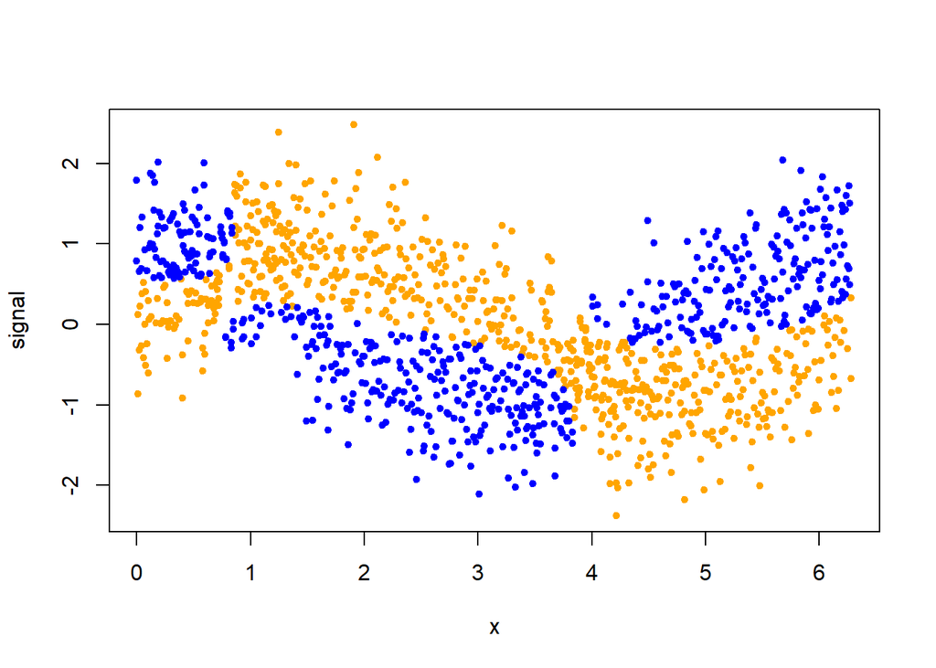

```r
plot(dataClasses[svmFit.radial$decision.values<0,1:2],pch=20,col="orange")
points(dataClasses[svmFit.radial$decision.values>0,1:2],pch=20,col="blue")
```

### 7.2.2 SVM with sigmoid kernel

Sigmoid kernel:
$$K(u,v)=\tanh(\gamma u \cdot v + coef_0).$$

```r
svmFit.sigmoid <- svm(class~., data = dataClasses,kernel="sigmoid")
summary(svmFit.sigmoid)
```

```
##
## Call:
## svm(formula = class ~ ., data = dataClasses, kernel = "sigmoid")
##
##
## Parameters:
##    SVM-Type:  eps-regression
##  SVM-Kernel:  sigmoid
##        cost:  1
##       gamma:  0.5
##      coef.0:  0
##     epsilon:  0.1
##
##
## Number of Support Vectors:  1256
```

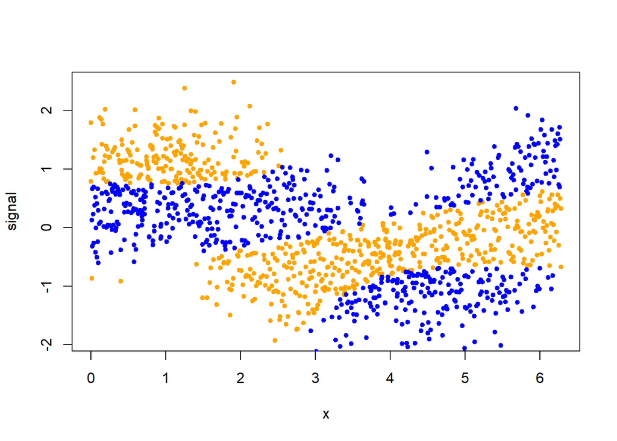

```r
plot(dataClasses[svmFit.sigmoid$decision.values<0,1:2],pch=20,col="orange")
points(dataClasses[svmFit.sigmoid$decision.values>0,1:2],pch=20,col="blue")
```

### 7.2.3 SVM with linear kernel

Linear kernel has formula
$$K(u,v)=u \cdot v.$$

```r
svmFit.linear <- svm(class~., data = dataClasses,kernel="linear")
summary(svmFit.linear)
```

```
##
## Call:
## svm(formula = class ~ ., data = dataClasses, kernel = "linear")
##
##
## Parameters:
##    SVM-Type:  eps-regression
##  SVM-Kernel:  linear
##        cost:  1
##       gamma:  0.5
##     epsilon:  0.1
##
##
## Number of Support Vectors:  1258
```

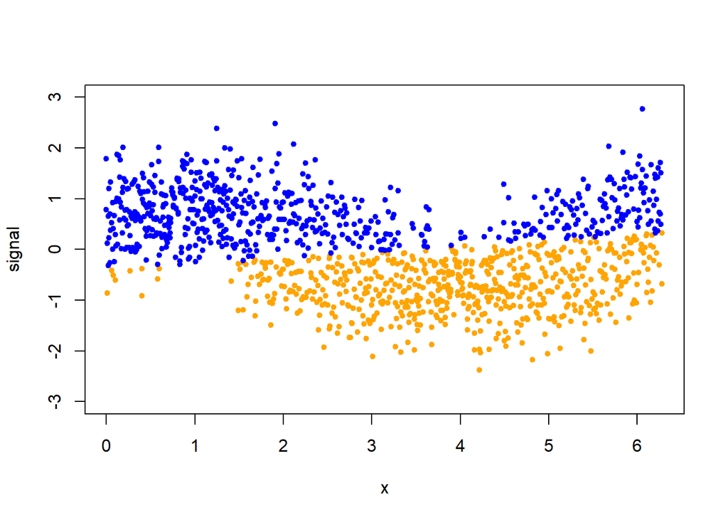

```r
plot(dataClasses[svmFit.linear$decision.values<0,1:2],ylim=c(-3,3),pch=20,col="orange")
points(dataClasses[svmFit.linear$decision.values>0,1:2],pch=20,col="blue")
```

### 7.2.4 SVM with polynomial kernel

Use polynomial kernel of degree 3 (default)
$$K(u,v)=(\gamma u \cdot v + coef_0)^d,$$
where $d=3$ is the degree of polynomial.

```r
svmFit.polynomial <- svm(class~., data = dataClasses,kernel="polynomial",degree=3)
summary(svmFit.polynomial)
```

```
##
## Call:
## svm(formula = class ~ ., data = dataClasses, kernel = "polynomial",
##     degree = 3)
##
##
## Parameters:
##    SVM-Type:  eps-regression
##  SVM-Kernel:  polynomial
##        cost:  1
##      degree:  3
##       gamma:  0.5
##      coef.0:  0
##     epsilon:  0.1
##
##
## Number of Support Vectors:  1214
```

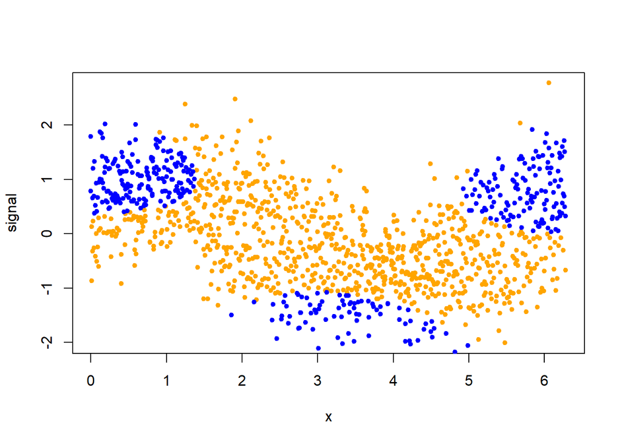

```r
plot(dataClasses[svmFit.polynomial$decision.values<0,1:2],pch=20,col="orange")
points(dataClasses[svmFit.polynomial$decision.values>0,1:2],pch=20,col="blue")
```

Polynomial kernel of degree 2 gives:

```r
svmFit.polynomial <- svm(class~., data = dataClasses,kernel="polynomial",degree=2)
summary(svmFit.polynomial)
```

```
##
## Call:
## svm(formula = class ~ ., data = dataClasses, kernel = "polynomial",
##     degree = 2)
##
##
## Parameters:
##    SVM-Type:  eps-regression
##  SVM-Kernel:  polynomial
##        cost:  1
##      degree:  2
##       gamma:  0.5
##      coef.0:  0
##     epsilon:  0.1
##
##
## Number of Support Vectors:  1197
```

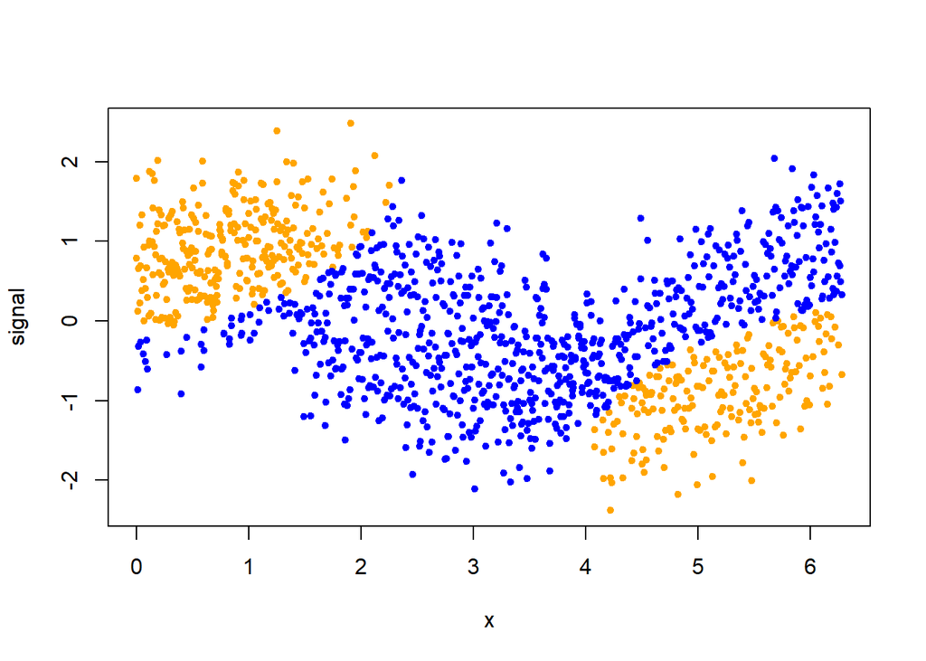

```r
plot(dataClasses[svmFit.polynomial$decision.values<0,1:2],pch=20,col="orange")
points(dataClasses[svmFit.polynomial$decision.values>0,1:2],pch=20,col="blue")
```

Polynomial kernel of degree 4 gives:

```r
svmFit.polynomial <- svm(class~., data = dataClasses,kernel="polynomial",degree=4)
summary(svmFit.polynomial)
```

```
##
## Call:
## svm(formula = class ~ ., data = dataClasses, kernel = "polynomial",
##     degree = 4)
##
##
## Parameters:
##    SVM-Type:  eps-regression
##  SVM-Kernel:  polynomial
##        cost:  1
##      degree:  4
##       gamma:  0.5
##      coef.0:  0
##     epsilon:  0.1
##
##
## Number of Support Vectors:  1233
```

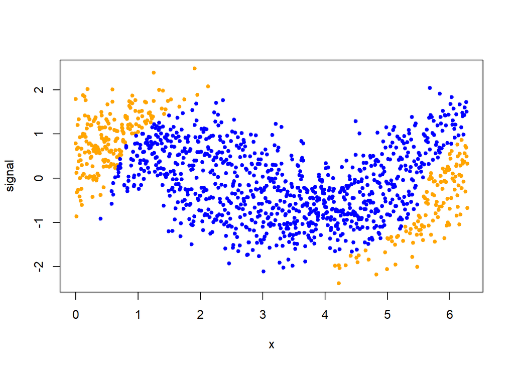

```r
plot(dataClasses[svmFit.polynomial$decision.values<0,1:2],pch=20,col="orange")
points(dataClasses[svmFit.polynomial$decision.values>0,1:2],pch=20,col="blue")
```

## 7.3 Example. Galton’s data

Galton’s data on the heights of parents and their children can be found in the package **HistData**.  
This data set lists the individual observations for 934 children in 205 families on which Galton (1886) based his cross-tabulation.

```r
library(HistData)
data(GaltonFamilies)
head(GaltonFamilies)
```

```
##   family father mother midparentHeight children childNum gender childHeight
## 1    001   78.5   67.0           75.43        4        1   male        73.2
## 2    001   78.5   67.0           75.43        4        2 female        69.2
## 3    001   78.5   67.0           75.43        4        3 female        69.0
## 4    001   78.5   67.0           75.43        4        4 female        69.0
## 5    002   75.5   66.5           73.66        4        1   male        73.5
## 6    002   75.5   66.5           73.66        4        2   male        72.5
```

Families are listed in decreasing order of `midparentHeight`. Reshuffle them to ensure correct cross validation procedure later.

```r
set.seed(0)
Data = GaltonFamilies[sample(nrow(GaltonFamilies)),
                      c("midparentHeight","childHeight","gender")]
kable(head(Data,5))
```

|  | midparentHeight | childHeight | gender |
| --- | --- | --- | --- |
| 398 | 67.94 | 67.0 | male |
| 836 | 67.00 | 62.5 | female |
| 679 | 68.54 | 68.2 | male |
| 129 | 72.76 | 74.0 | male |
| 930 | 66.64 | 64.0 | male |

Note that mid-parent height is calculated as `midparentHeight = (father + 1.08*mother)/2`.

Predict gender of the child by her or his height and mid-parent height.  
Plot the data scatterplot.

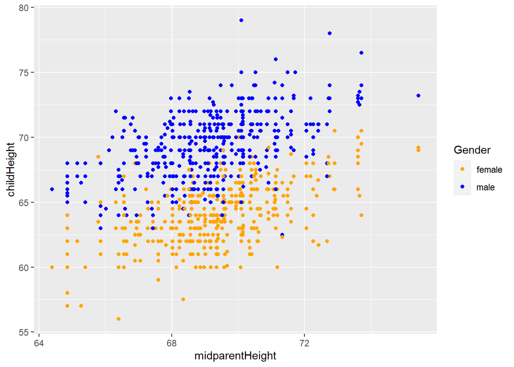

```r
Gender = as.character(Data$gender)
ggplot(Data, aes(x=midparentHeight, y=childHeight, color=Gender)) +
  geom_point(shape=16)+scale_color_hue(l=65, c=100)+
  scale_color_manual(values=c("orange", "blue"))
```

Recall that logistic regression classification accuracy of this data, calculated in the lecture Classification and Regression Trees was 0.881.

Partition data into train (2/3) and test (1/3) sets.

```r
testInd = sample(nrow(Data), trunc(nrow(Data)/3))
xTrain = Data[-testInd,]
xTest = Data[testInd,]
```

Fit the model with default parameters to the train set and predict classes using the test set. The class label column should not be used the test data.

```r
svmFit <- svm(gender~., data = xTrain)
predict <- predict(svmFit, xTest[,!names(xTest)=="gender"])
```

Function `table()` returns confusion matrix.

```r
(conf <- table(pred = predict, true = xTest[,"gender"]))
```

```
##         true
## pred     female male
##   female    138   27
##   male       18  128
```

The prediction accuracy can be calculated by

```r
classAgreement(conf)$diag
```

```
## [1] 0.8553055
```

Now play with parameters of the method.

The package provides function `tune` which tunes hyperparameters of statistical methods using a grid search over supplied parameter ranges.

Optimize for parameters `gamma` and `cost`.

It is important to understand the influence of these two parameters, because the accuracy of an SVM model is largely dependent on them.

```r
svmTuned <- tune.svm(gender~., data = Data, gamma = 10^(-4:-1), cost = 5*(1:4))
summary(svmTuned)
```

```
##
## Parameter tuning of 'svm':
##
## - sampling method: 10-fold cross validation
##
## - best parameters:
##  gamma cost
##   0.01   15
##
## - best performance: 0.1145962
##
## - Detailed performance results:
##    gamma cost     error dispersion
## 1  1e-04    5 0.1519904 0.02773120
## 2  1e-03    5 0.1156600 0.02311329
## 3  1e-02    5 0.1199268 0.02511533
## 4  1e-01    5 0.1177877 0.01754002
## 5  1e-04   10 0.1253031 0.01911761
## 6  1e-03   10 0.1177991 0.02427320
## 7  1e-02   10 0.1177991 0.02578056
## 8  1e-01   10 0.1167124 0.02224028
## 9  1e-04   15 0.1210021 0.01612681
## 10 1e-03   15 0.1167353 0.02295421
## 11 1e-02   15 0.1145962 0.02331117
## 12 1e-01   15 0.1167239 0.02228966
## 13 1e-04   20 0.1178106 0.01617700
## 14 1e-03   20 0.1188630 0.02341725
## 15 1e-02   20 0.1167353 0.02509321
## 16 1e-01   20 0.1167239 0.02392233
```

The object `svmTuned` contains among others the component `best.parameters`:

```r
svmTuned$best.parameters
```

```
##    gamma cost
## 11  0.01   15
```

It also contains `best.model` - the model trained on the complete training data using the best parameters.  
The following command will produce the graph, in which support vectors are shown as ‘X’, true classes are highlighted through symbol color, and predicted class regions are visualized using colored background.

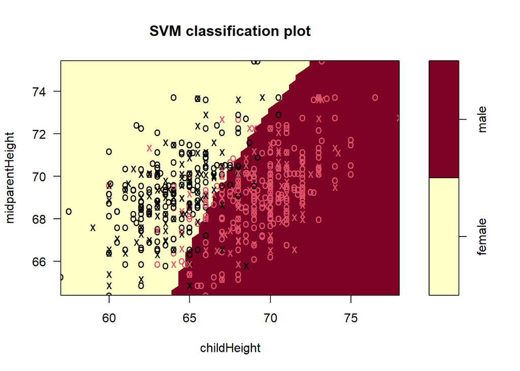

```r
plot(svmTuned$best.model,xTrain)
```

Finally, predict test set classes and get the accuracy.

```r
predict <- predict(svmTuned$best.model, xTest[,!names(Data)=="gender"])
classAgreement(table(pred = predict, true = xTest[,"gender"]))$diag
```

```
## [1] 0.8553055
```

## 7.4 Example. Rectangular class domain

Simulate the data with rectangular class shape, like in lecture 6 when we examined tree classification.  
Each observation is three-dimensional vector with two numeric features and one categorical response (type) with possible values ‘Positive’ or ‘Negative’.  
The goal is to predict type on the basis of first two features.

Simulate the data.

```r
N = 1000
xPos = 0.2
yMinPos = 0.2
yMaxPos = 0.7
set.seed(0)
newData = data.frame(y=runif(N),x=runif(N))
newData$type = with(newData,ifelse(x>xPos & y>yMinPos & y<yMaxPos,
                        'Positive','Negative'))
```

Add some noise and reshuffle.

```r
n = N/10
newData$type[1:n] = c('Positive','Negative')[1+rbinom(n, 1, 0.5)]
newData = newData[sample(nrow(newData)),]
```

Plot the data

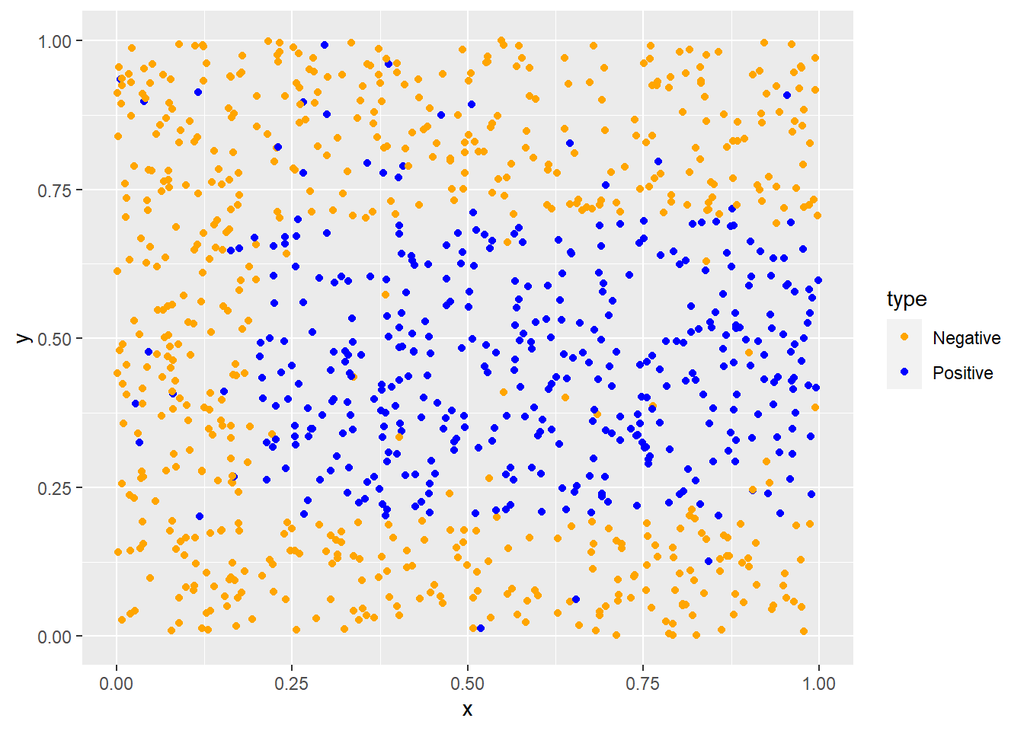

```r
rect <- ggplot(newData, aes(x=x, y=y, color=type)) +
  geom_point(shape=16)+scale_color_hue(l=65, c=100)+
  scale_color_manual(values=c("orange", "blue"))
rect
```

Partition the data into train (2/3) and test (1/3) sets.  
Fit SVM model with default parameters to the data.  
Then try to improve the model, tuning `gamma` and `cost` parameters.  
Use different kernels and compare the results.

- Make variable `type` a factor
- Create test and train samples by randomly selecting one third of observations as test and the rest as train samples; use `set.seed(7849)` for better reproducibility.
- Fit SVM to train data with some `gamma`, `cost` and a choice of kernel
- Predict type of the test data with actual column `type` excluded
- Calculate confusion table

(Skipped Code)

You may observe results of confusion matrix `conf` as following:

```r
classAgreement(conf)$diag
```

```
## [1] 0.9309309
```

Continue by tuning the parameters using function `tune.svm()`.

- Select ranges for `gamma` and `cost`
- Run `tune.svm()` to search for the optimal setting on the grid

(Skipped Code)

Observe the summary of the search

```r
summary(svmTuned)
```

```
##
## Parameter tuning of 'svm':
##
## - sampling method: 10-fold cross validation
##
## - best parameters:
##  gamma cost
##    0.1   10
##
## - best performance: 0.09167797
##
## - Detailed performance results:
##    gamma cost      error dispersion
## 1  1e-04    5 0.38392130 0.05872924
## 2  1e-03    5 0.38392130 0.05872924
## 3  1e-02    5 0.28496156 0.04841088
## 4  1e-01    5 0.09314790 0.04173101
## 5  1e-04   10 0.38392130 0.05872924
## 6  1e-03   10 0.38392130 0.05872924
## 7  1e-02   10 0.22200362 0.03789782
## 8  1e-01   10 0.09167797 0.04726509
## 9  1e-04   15 0.38392130 0.05872924
## 10 1e-03   15 0.38392130 0.05872924
## 11 1e-02   15 0.17550882 0.04278668
## 12 1e-01   15 0.09466305 0.04699442
## 13 1e-04   20 0.38392130 0.05872924
## 14 1e-03   20 0.38392130 0.05872924
## 15 1e-02   20 0.15897784 0.04771210
## 16 1e-01   20 0.09167797 0.04673847
```

Plot the results of classification.

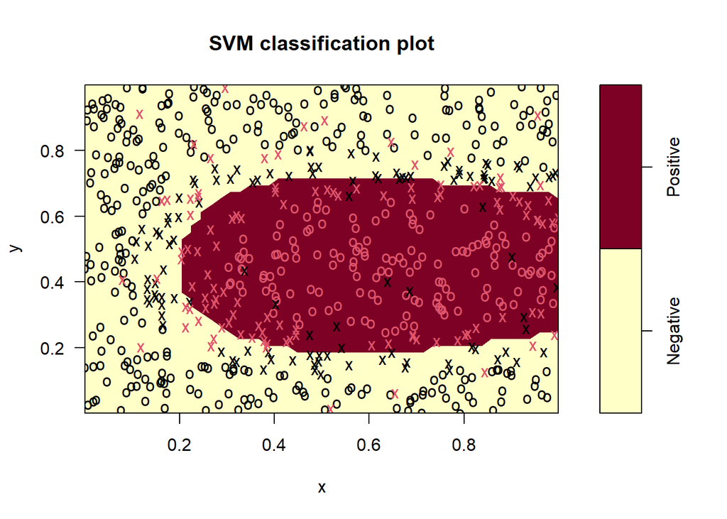

```r
plot(svmTuned$best.model,xTrain)
```

Predict the type and calculate accuracy of the tuned model.

```r
predict <- predict(svmTuned$best.model, xTest[,!names(xTest)=="type"])
classAgreement(table(pred = predict, true = xTest[,"type"]))$diag
```

```
## [1] 0.9189189
```

**Summary**.

## 7.5 Otto Product Classification Example

Consider again Otto Group Product Classification Example and compare SVM results with performance of random forest and gradient boosting.

## 7.6 Data

Load the data set.

```r
library(fBasics)
```

```r
Data = read.csv(paste(datapath,'DTTrain.csv',sep='/'),header=TRUE,
                stringsAsFactors = TRUE)
dim(Data) # dataset dimensions
```

```
## [1] 10233    95
```

```r
head(Data)
```

```
##     time feat_1 feat_2 feat_3 feat_4 feat_5 feat_6 feat_7 feat_8 feat_9 feat_10
## 1  45652      0      0      0      0      0      0      0      0      0       2
## 2 225646      0      0      0      0      0      0      0      1      0       0
## 3 345735      0      0      0      0      0      0      0      2      0       0
## 4 436478      0      0      0      0      0      0      0      1      0       0
## 5 478129      0      0      0      0      0      0      0      1      0       0
## 6 524475      0      0      0      0      0      0      0      0      0       0
##   feat_11 feat_12 feat_13 feat_14 feat_15 feat_16 feat_17 feat_18 feat_19
## 1       0       0       2       3       1       5       0       0       1
## 2       0       0       0       0       2       3       0       0       0
## 3       0       0       0       3       1       0       0       0       0
## 4       0       0       0       0       0       0       0       0       0
## 5       0       0       1       0       0       0       0       0       0
## 6       0       0       0       0       0       0       0       1       0
##   feat_20 feat_21 feat_22 feat_23 feat_24 feat_25 feat_26 feat_27 feat_28
```

[output cut: 62 more lines]

```r
# data content
kable(head(Data[,1:5],3))
```

| time | feat_1 | feat_2 | feat_3 | feat_4 |
| --- | --- | --- | --- | --- |
| 45652 | 0 | 0 | 0 | 0 |
| 225646 | 0 | 0 | 0 | 0 |
| 345735 | 0 | 0 | 0 | 0 |

```r
kable(Data[1:3,(ncol(Data)-4):ncol(Data)])
```

| feat_90 | feat_91 | feat_92 | feat_93 | target |
| --- | --- | --- | --- | --- |
| 0 | 0 | 1 | 0 | Class_5 |
| 0 | 1 | 1 | 0 | Class_3 |
| 0 | 0 | 0 | 0 | Class_5 |

Partition data into train (2/3) and test (1/3) sets.

```r
set.seed(0)
testInd = sample(nrow(Data), trunc(nrow(Data)/3))
xTrain = Data[-testInd,-1]
xTest = Data[testInd,-1]
```

## 7.7 Fitting SVM

Fit SVM to the train data and make prediction on the test data.  
Function `predict()` has logical parameter `probability` indicating that required return is in the format of class probabilities.  
It is possible only if the model was fitted with the probability option enabled. Recall that SVM does not calculate probabilities of classes naturally, it is done “outside” the model.

```r
svmFit <- svm(target~., data = xTrain,probability = TRUE)
predict <- predict(svmFit, xTest[,!names(xTest)=="target"],
                   probability = TRUE)
```

If probability is TRUE, `predict()` includes “probabilities” attribute containing a $n \times k$ matrix ($n$ number of predicted values, $k$ number of classes) of class probabilities.

```r
prob = attr(predict, "probabilities")
kable(head(prob,3))
```

|  | Class_5 | Class_3 | Class_4 | Class_2 | Class_1 |
| --- | --- | --- | --- | --- | --- |
| 9614 | 0.0010774 | 0.0004066 | 0.4728616 | 0.4843433 | 0.0413112 |
| 1017 | 0.0767463 | 0.0019650 | 0.6824796 | 0.1622696 | 0.0765395 |
| 8004 | 0.0000000 | 0.9999997 | 0.0000001 | 0.0000001 | 0.0000001 |

```r
prob = prob[,sort(colnames(prob))]
kable(head(prob,3))
```

|  | Class_1 | Class_2 | Class_3 | Class_4 | Class_5 |
| --- | --- | --- | --- | --- | --- |
| 9614 | 0.0413112 | 0.4843433 | 0.0004066 | 0.4728616 | 0.0010774 |
| 1017 | 0.0765395 | 0.1622696 | 0.0019650 | 0.6824796 | 0.0767463 |
| 8004 | 0.0000001 | 0.0000001 | 0.9999997 | 0.0000001 | 0.0000000 |

Use Multiclass logloss for estimating prediction quality.

```r
MultiLogLoss <- function(act, pred)
{
  eps = 1e-15;
  nr <- nrow(pred)
  pred = matrix(sapply( pred, function(x) max(eps,x)), nrow = nr)
  pred = matrix(sapply( pred, function(x) min(1-eps,x)), nrow = nr)
  #normalize rows
  ll = sum(act*log(sweep(pred, 1, rowSums(pred), FUN="/")))
  ll = -ll/nrow(act)
  return(ll);
}
```

Calculate accuracy and logloss.

```r
conf <- table(pred = predict, true = xTest[,"target"])
classAgreement(conf)$diag
```

```
## [1] 0.8783348
```

```r
target_IndMat<-model.matrix(~xTest[,"target"]-1)
unname(target_IndMat[1:10,])
```

```
##       [,1] [,2] [,3] [,4] [,5]
##  [1,]    0    1    0    0    0
##  [2,]    0    0    0    1    0
##  [3,]    0    0    1    0    0
##  [4,]    1    0    0    0    0
##  [5,]    0    0    0    0    1
##  [6,]    0    1    0    0    0
##  [7,]    0    1    0    0    0
##  [8,]    0    0    0    0    1
##  [9,]    0    0    0    0    1
## [10,]    0    1    0    0    0
```

```r
print(MultiLogLoss(target_IndMat,prob))
```

```
## [1] 0.3551276
```

With default parameters SVM outperforms random forest and gradient boosting.  
However, it is still not easy to select the right method for the data: there are many parameters to be tuned, especially in SVM and gradient boosting.

Visualize manifold of class domain shapes created by SVM.

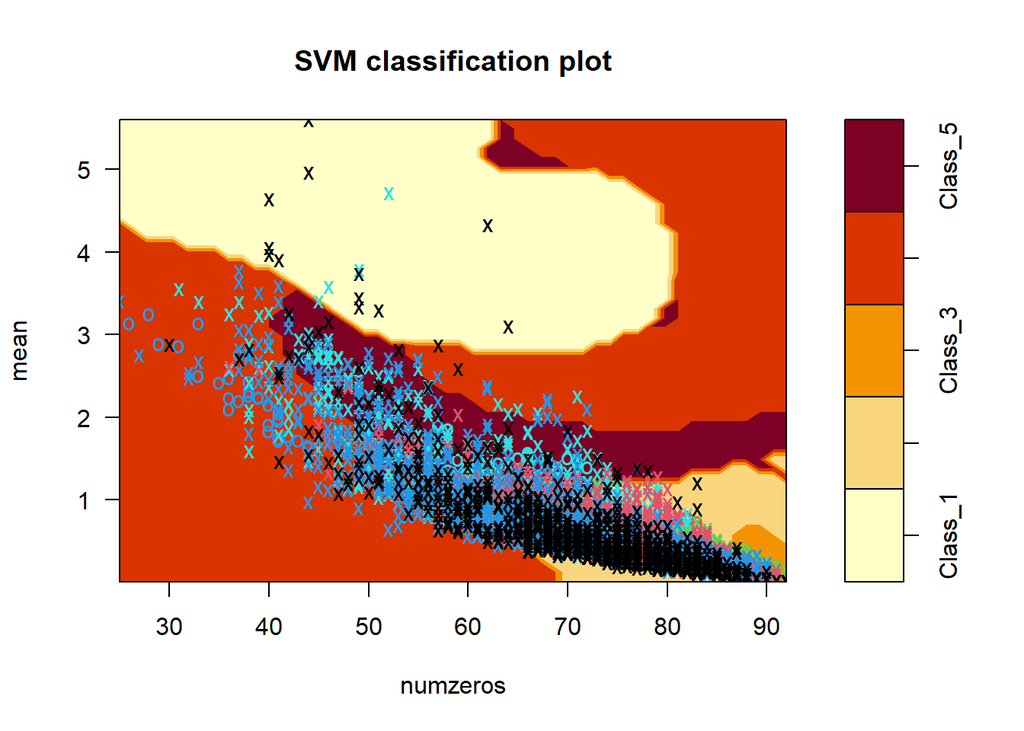

```r
xTrain = data.frame(mean=rowMeans(Data[,-c(1,ncol(Data))]),
                    numzeros=rowSums(Data==0),
                    target=Data$target)
svmFit <- svm(target~., data = xTrain)
plot(svmFit,xTrain)
```

# 8 Advantages and Disadvantages of SVM

According to the [documentation of scikit-learn Python package](http://scikit-learn.org/stable/modules/svm.html) the advantages of support vector machines are:

- Effective in high dimensional spaces
- Never gets trapped in local minima
- Still effective in cases where number of dimensions is greater than the number of samples
- Uses a subset of training points in the decision function (called support vectors), so it is also memory efficient
- Versatile: different Kernel functions can be specified for the decision function

The disadvantages of support vector machines include:

- SVM may overfit
- SVMs do not directly provide probability estimates, these are calculated using an expensive five-fold cross-validation
- SVM does not return importance of features